# Southern New Hampshire University

ReMap: FYE-101 Task & Email (UG)

Karen West | k.west2@snhu.edu

Publication Date: 2021-03-26 Updated: 2021-05-20

## Overview

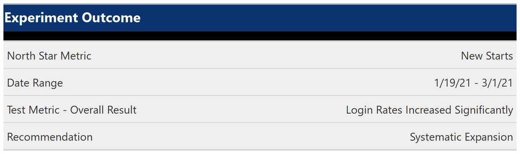

**Theory:** The FYE-101 course is a free introductory orientation course designed to help new students familiarize themselves with the learning management system. It is thought that if students log into this free course prior to their first term, they will be more prepared to start classes, and potentially less likely to drop or “melt”.

**Hypothesis:** Outreaching students to encourage them to log into FYE-101 will improve FYE-101 login rates.

## Test Design

**Test Metric:** FYE-101 Login Rate, calculated as:
$$FYE101 Login Rate = \sum_{n=FYE101 Logins} / \sum_{n=Total Registered Students}$$

**Testing Groups:** Of all eligible members of the population (full criteria list below), control and experiment groups were assigned using the random split feature in Marketing Cloud.

- Control Group: **50%** received no emails or tasks
- Experiment Group: **50%** received FYE-101 email and task was created on the Unify record

Tasks were created on Tuesday each week and emails were also sent during the experiment timeframe on the same day as task creation. These treatments only occurred the first week that the student was eligible (see below) to receive; they did not occur on a weekly basis.

**Experiment Population Eligibility (AKA InPopulation):**

- UG students with a planned term start of 21EW4
- Student has been registered for at least 24 hours
- Student has not logged into FYE-101

### Example Email

[figure not shown]

### Example Task

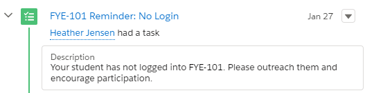

## Outcomes & Learnings

**Overall Results:** As of 3/26/21, the FYE-101 Login Rate for the test group was **4.1 percentage points higher (+4.8% change)**. This difference is statistically significant with a 95% confidence level and two-sided test of proportions. See appendix for more detail on how to interpret the results.

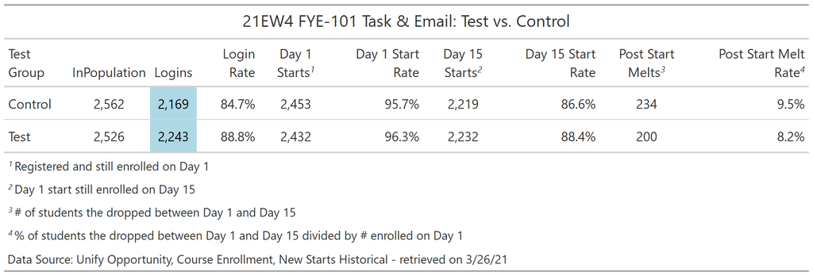

**Learnings:**

- **Melt Rate** The post-start melt rate for the test group was **-1.3 percentage points lower (-13.8% change)**. This difference is not statistically significant with a 95% confidence level and two-sided test of proportions. Even though this is not statistically significant, the lower melt rate is a positive indication of the potential influence of student engagement with the course and therefore there is a likely benefit to systematic expansion.

**Next Steps:**

*Systematic Expansion* This task will be added to all new students registered for classes going forward. Students will receive the email the first time they are eligible to receive (registered for 24 hours, no login into FYE-101), but the tasks will be generated on a weekly basis even if there already was a task generated in a previous week.

## Glossary of Terms

**FYE:** First Year Experience

## Appendix

**Interpreting the Results**

- **Confidence Level:** The percentage of confidence that the result is a consequence of the change made or treatment administered and not a result of random chance. A 95% confidence interval indicates that we are 95% confident the test result is not due to random chance.
- **Statistical Significance:** A test result is said to be “statistically significant” when the difference between the results of the test and control groups is too big to have been a result of chance.
- **One-Sided vs. Two-Sided Test** A one sided test is used when we only want to prove that the *increase* in conversions (i.e. the metric) that occurred for the test group is significant; it does not consider whether any *decrease* in conversions is significant. A two-sided test evaluates the significance of the test group conversions being higher *or* lower as compared to the control. If we want to be certain that a treatment being tested does not have a negative impact on the metric, then a two-sided test should be conducted.

**Updates** 5/20: Corrected wording of treatment received for the test group in the Test Design section (originally had the wording of control/test groups reversed).